# L’àmbit municipal i el vot a Vox

Ruben Pueyo i David Donaire

2023-03-08

```r
logit <- function(p,eps = 0.001){
  p[p==0] <- eps
  p[p==1] <- 1-eps
  return(log(p/(1-p)))
}
```

###Funcions per anàlisi bivariat/propensions

```r
errStd_bin <- function(x) { sqrt(mean(x)*(1-mean(x)) / length(x))}
minInt_bin <- function(x) { mean(x) - 1.96 *errStd_bin(x) }
maxInt_bin <- function(x) { mean(x) + 1.96 *errStd_bin(x) }
```

# 1. Introducció

Els discursos de la formació d’extrema dreta Vox se centren, en la lluita contra l’avortament, l’ecologisme, la immigració, els moviments feministes i els moviments LGTBIQ+. En el present treball veurem si hi ha una correlació entre els municipis amb una major taxa d’immigració o avortament, entre altres variables independents, i el vot a la formació de Santiago Abascal. És a dir, sense entrar en si suposen pors racionals o no, si hi ha una correlació en una major presència d’aquests fenòmens als quals Vox mostra un clar rebuig i una major suport en les localitats més afectades per aquests suposats problemes.

La metodologia utilitzada per a analitzar la nostra pregunta de recerca és completament quantitativa. Durem a terme una regressió múltiple per a identificar les correlacions entre el suport municipal a la formació verda i les diferents variables independents que puguin explicar parcialment la diferència de suport entre municipis.

Per poder realitzar el nostre estudi, s’ha realitzar una recopilació de dades mitjançant el padró municipal, la estadística municipal de l’atur de l’INE, un número d’indicadors econòmics del municipi i els resultats electorals municipals per al Congrés dels diputats. L’atur s’ha pres a data de novembre de 2019, donat que aquest any es van a dur a terme dues eleccions en pocs mesos, i la situació personal d’atur a aquelles dates podria haver afectat el vot.

```r
data <- read.csv("C:/Users/rpuey/Documents/datosfinal.txt")
```

```r
data <- rename(data, pob_t = totalpoblacion, mun = municipio)
names(data)
```

```
##  [1] "mun"                     "Votosenblanco"
##  [3] "Votosnulos"              "PSOE"
##  [5] "PP"                      "Cs"
##  [7] "ERC"                     "VOX"
##  [9] "JUNTS"                   "PNV"
## [11] "PODEMOS_IU"              "EH_Bildu"
## [13] "BNG"                     "CUP"
## [15] "atur"                    "aturhomesmenors24"
## [17] "aturhomes25_44"          "aturhomesmes45"
## [19] "aturdonesmenors24"       "aturdones25_44"
## [21] "aturdonesmajors45"       "aturagricultura"
## [23] "aturindustria"           "aturconstruccio"
## [25] "aturserveis"             "americana"
## [27] "asiatica"                "europeossinespanyoles"
## [29] "pob_t"                   "espaÃ.oles"
## [31] "totalunioneuropea"       "ambosexostotalamericana"
## [33] "totaloceaniayapatridas"  "totalhombres"
## [35] "totalextranjeros"        "totalafrica"
## [37] "totalasia"               "totalmujeres"
## [39] "mujeresespanyolas"       "hombresespanyoles"
## [41] "menores"                 "edad20_29"
## [43] "edad30_39"               "edad40_49"
## [45] "edad50_59"               "edad60_69"
## [47] "edad70_79"               "mayores80"
```

```r
data <- mutate(data,
               esp = espaÃ.oles/pob_t,
               euro = europeossinespanyoles/pob_t,
               asia = totalasia/pob_t,
               ame = americana/pob_t,
               UE = totalunioneuropea/pob_t,
               oce_apa = totaloceaniayapatridas/pob_t,
               afr = totalafrica/pob_t,
               h = totalhombres/pob_t,
               m = totalmujeres/pob_t,
               m19 = menores/pob_t,
               e20_29 = edad20_29/pob_t,
               e30_39 = edad30_39/pob_t,
               e40_49 = edad40_49/pob_t,
               e50_59 = edad50_59/pob_t,
               e60_69 = edad60_69/pob_t,
               e70_79 = edad70_79/pob_t,
               M80 = mayores80/pob_t)

data <- mutate(data, esp = espaÃ.oles/pob_t,euro = europeossinespanyoles/pob_t, asia = totalasia/pob_t, ame = americana/pob_t, UE = totalunioneuropea/pob_t, oce_apa = totaloceaniayapatridas/pob_t, afr = totalafrica/pob_t, h = totalhombres/pob_t, m = totalmujeres/pob_t, m19 = menores/pob_t,e20_29 = edad20_29/pob_t, e30_39 = edad30_39/pob_t, e40_49 = edad40_49/pob_t, e50_59 = edad50_59/pob_t,e60_69 = edad60_69/pob_t, e70_79 = edad70_79/pob_t,M80 = mayores80/pob_t)
```

```r
padro <- readRDS(file = "data/SEPE/df_sepe_hist_m_padro.RDS")
congres <- readRDS(file="data/electorals/d0911_esp_con_2019_mun.RData")
congres <- aggregate(congres[,colnames(congres)[-c(1:5)]],list(id_mun = substr(congres$id_sscc, 1, 5)), sum, na.rm = TRUE)
suma <- merge(congres, padro)
data1 <- suma[suma$ANY == 2019,]
```

```r
data1 <- rename(data1, mun = id_mun)
```

```r
data1 <- mutate(data1, v_blanc = n_vot_blanco/n_escrutinio_censo, v_nul = n_vot_nulos/n_escrutinio_censo, PSOE_p = PSOE/n_escrutinio_censo, PP_p = PP/n_escrutinio_censo, Cs_p = Cs/n_escrutinio_censo, ERC_p = ERC/n_escrutinio_censo, VOX_p = VOX/n_escrutinio_censo, JUNTS_p = JUNTS/n_escrutinio_censo, PNV_p = PNV/n_escrutinio_censo, PODEMOS_p = PODEMOS_IU/n_escrutinio_censo, Bildu_p = EH_Bildu/n_escrutinio_censo, BNG_p = BNG/n_escrutinio_censo, CUP_p = CUP/n_escrutinio_censo)
```

```r
data$mun <- sprintf("%05d", as.numeric(data$mun))
```

```r
d <- merge(data, data1, by = c("mun"))
```

```r
d1 <- data.frame(d$mun, d$v_blanc, d$v_nul, d$PSOE_p, d$PP_p, d$Cs_p, d$ERC_p, d$VOX_p, d$JUNTS_p, d$PNV_p, d$PODEMOS_p, d$Bildu_p, d$BNG_p, d$CUP_p, d$t_atur, d$t_atur_m24, d$t_atur_25_44, d$t_atur_M45, d$t_atur_h, d$t_atur_d, d$pob_t, d$esp, d$euro, d$asia, d$ame, d$UE, d$oce_apa, d$afr,d$h, d$m, d$m19,d$e20_29, d$e30_39, d$e40_49, d$e50_59, d$e60_69,d$e70_79, d$M80)

d1 <- rename(d1, mun= d.mun, v_blanc= d.v_blanc, v_nul= d.v_nul, PSOE= d.PSOE_p, PP= d.PP_p, Cs= d.Cs_p, ERC= d.ERC_p, VOX= d.VOX_p, JUNTS= d.JUNTS_p, PNV= d.PNV_p, PODEMOS= d.PODEMOS_p, Bildu= d.Bildu_p, BNG= d.BNG_p, CUP= d.CUP_p, atur= d.t_atur, atur_m24= d.t_atur_m24, atur_25_44= d.t_atur_25_44, atur_M45= d.t_atur_M45, atur_h= d.t_atur_h, atur_d= d.t_atur_d, pob_t= d.pob_t, esp= d.esp, euro= d.euro, asia= d.asia, ame= d.ame, UE= d.UE, oce_apa= d.oce_apa, afr= d.afr,h= d.h, m= d.m, m19= d.m19,e20_29= d.e20_29, e30_39= d.e30_39, e40_49= d.e40_49, e50_59= d.e50_59, e60_69= d.e60_69,e70_79= d.e70_79, M80= d.M80)
```

```r
names(d1)
```

```
##  [1] "mun"        "v_blanc"    "v_nul"      "PSOE"       "PP"
##  [6] "Cs"         "ERC"        "VOX"        "JUNTS"      "PNV"
## [11] "PODEMOS"    "Bildu"      "BNG"        "CUP"        "atur"
## [16] "atur_m24"   "atur_25_44" "atur_M45"   "atur_h"     "atur_d"
## [21] "pob_t"      "esp"        "euro"       "asia"       "ame"
## [26] "UE"         "oce_apa"    "afr"        "h"          "m"
## [31] "m19"        "e20_29"     "e30_39"     "e40_49"     "e50_59"
## [36] "e60_69"     "e70_79"     "M80"
```

Renda

```r
df01_W_2019 <- readRDS(file="data/ine/dadesRENTA_01_2019.rds")
df09_W_2019 <- readRDS(file="data/ine/dadesRENTA_09_2019.rds")
df10_W_2019 <- readRDS(file="data/ine/dadesRENTA_10_2019.rds")

dades_sscc<-merge(df01_W_2019,df09_W_2019)
dades_sscc <- merge(dades_sscc,df10_W_2019)

dades_socio_mun <- dades_sscc %>%
  mutate(id_mun = substr(id_sscc,1,5)
         ,Pob_renta = ifelse(is.na(Renta_neta_media_por_persona_),NA,Población)
         ,Renta_Pob = ifelse(is.na(Población),NA,Renta_neta_media_por_persona_)
         ,Pob_gini = ifelse(is.na(Índice_de_Gini),NA,Población)
         ,Gini_Pob = ifelse(is.na(Población),NA,Índice_de_Gini)
         ,Pob_edad = ifelse(is.na(Edad_media_de_la_población),NA,Población)
         ,Edad_Pob = ifelse(is.na(Población),NA,Edad_media_de_la_población)
         ,tam_hog_Pob = ifelse(is.na(Población),NA,Tamaño_medio_del_hogar)
         ,Por_hog_uni_Pob = ifelse(is.na(Población),NA,Porcentaje_de_hogares_unipersonales)
         ) %>%
  group_by(id_mun) %>%
  summarise(Renta_neta_persona = sum(Renta_Pob*Pob_renta,na.rm=TRUE)/sum(Pob_renta,na.rm=TRUE)
            ,Gini_medio = median(Índice_de_Gini,na.rm=TRUE)
            ,Edad_media = sum(Edad_Pob*Pob_edad,na.rm=TRUE)/sum(Pob_edad,na.rm=TRUE)
            ,Poblacion = sum(Población,na.rm=TRUE)
            ,tam_hog_medio = sum(tam_hog_Pob*Pob_edad,na.rm=TRUE)/sum(Pob_edad,na.rm=TRUE)
            ,por_hog_uni = sum(Por_hog_uni_Pob*Pob_edad,na.rm=TRUE)/sum(Pob_edad,na.rm=TRUE)
            ) %>%
  ungroup() %>%
  filter(Poblacion>0)

d1 <- merge(d1,dades_socio_mun,by.x="mun",by.y="id_mun")
d1 <- na.omit(d1)
```

## 1.1. Rellevància i pertinència

Particularment a nosaltres no ens interessa fer recerca sense un motiu o interès més enllà de l’avanç de les ciències polítiques. Volem que el treball serveixi per a entendre millor per què la gent es decideix a votar per la formació d’extrema dreta a Espanya. També que aquest treball pugui ser utilitzat per alcaldies per a prevenir una expansió de l’extrema dreta a nivell local. Després dels resultats es podrà deduir si les pors als quals fa referència Vox són demandes insatisfetes pels governs locals a la població més afectada.

## 1.2. Pregunta d’investigació i hipòtesis

Pregunta d’investigació: hi ha una correlació entre variables independents i el vot a VOX en eleccions municipals a Espanya?

Variable dependent: vot a VOX en les municipals

5 variables independents claus: 1. Atur 2. Percentatge d’immigrants 3. Edat 4. Sexe, 5. Percentatge de vot a partits nacionalistes

# 2. Variables

## 2.1. Anàlisi univariant

### 2.1.1. Percentatge de vot a Vox (Variable dependent)

```r
summary(d1$VOX)
```

```
##    Min. 1st Qu.  Median    Mean 3rd Qu.    Max.
## 0.00000 0.05788 0.10198 0.10178 0.13939 0.45045
```

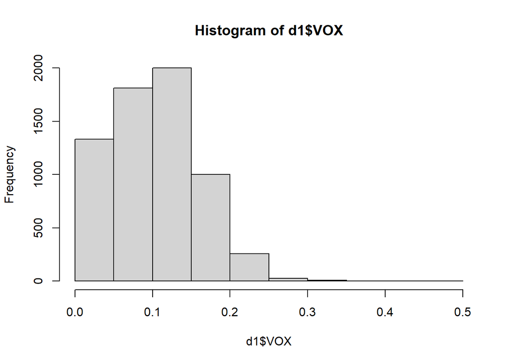

```r
hist(d1$VOX)
```

### 2.1.2. Atur (Variable independent)

#### Atur total

```r
summary(d1$atur)
```

```
##    Min. 1st Qu.  Median    Mean 3rd Qu.    Max.
## 0.00000 0.05723 0.08112 0.08729 0.11221 0.27778
```

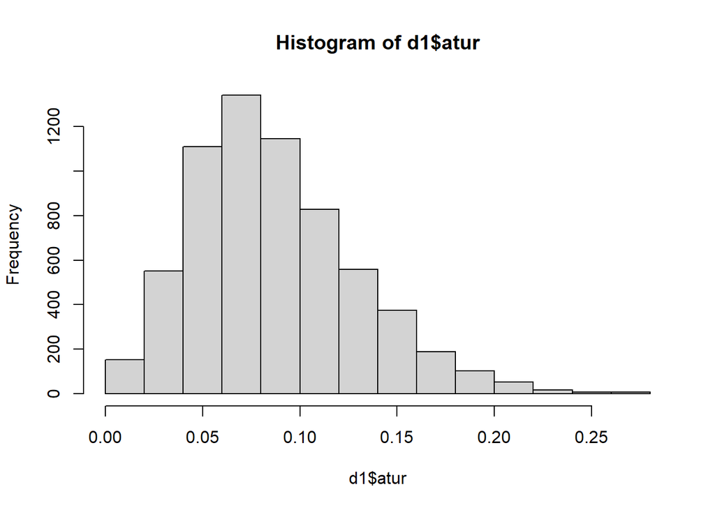

```r
hist(d1$atur)
```

#### Atur de les persones menors de 24 anys

```r
summary(d1$atur_m24)
```

```
##    Min. 1st Qu.  Median    Mean 3rd Qu.    Max.
## 0.00000 0.02427 0.04571 0.05336 0.07217 0.58333
```

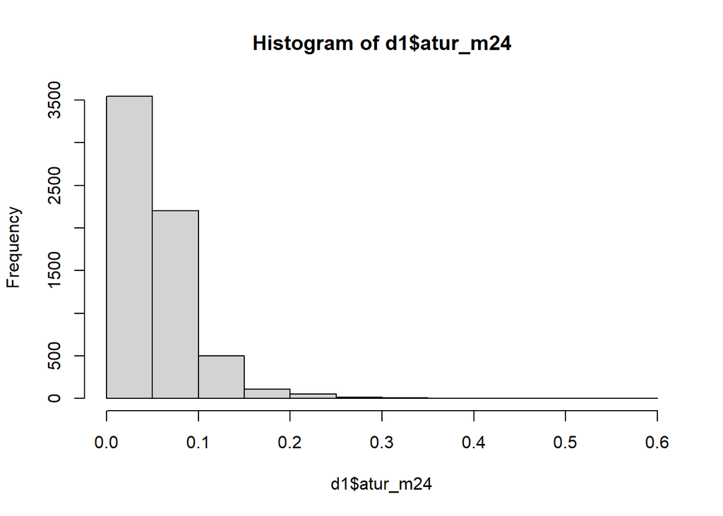

```r
hist(d1$atur_m24)
```

#### Atur de les persones entre 25 i 44 anys

```r
summary(d1$atur_25_44)
```

```
##    Min. 1st Qu.  Median    Mean 3rd Qu.    Max.
## 0.00000 0.05342 0.07979 0.08567 0.11193 0.34677
```

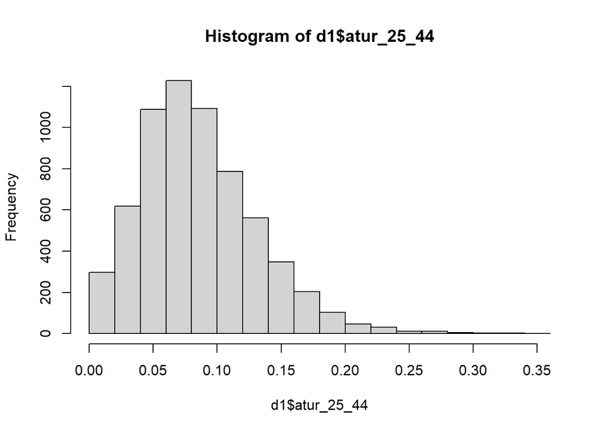

```r
hist(d1$atur_25_44)
```

#### Atur de les persones majors de 45 anys

```r
summary(d1$atur_M45)
```

```
##    Min. 1st Qu.  Median    Mean 3rd Qu.    Max.
## 0.00000 0.06251 0.09161 0.09842 0.12746 0.42460
```

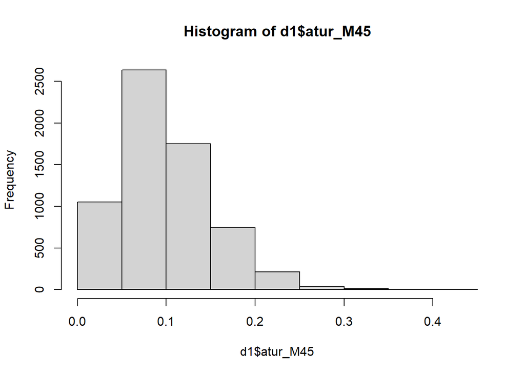

```r
hist(d1$atur_M45)
```

### 2.1.3. Percentatge d’immigrants

#### Població total

```r
summary(d1$pob_t)
```

```
##    Min. 1st Qu.  Median    Mean 3rd Qu.    Max.
##      62     289     858    7136    3387 3266126
```

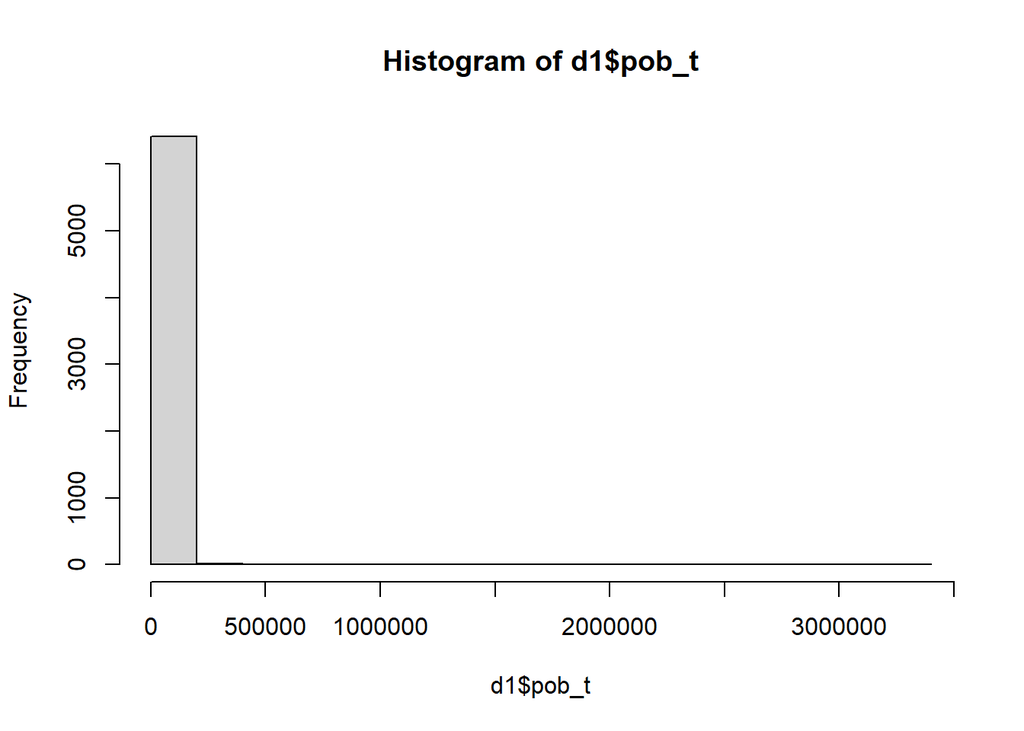

```r
hist(d1$pob_t)
```

#### Espanya

```r
summary(d1$esp)
```

```
##    Min. 1st Qu.  Median    Mean 3rd Qu.    Max.
## 0.09291 0.90495 0.95236 0.92949 0.97866 1.00000
```

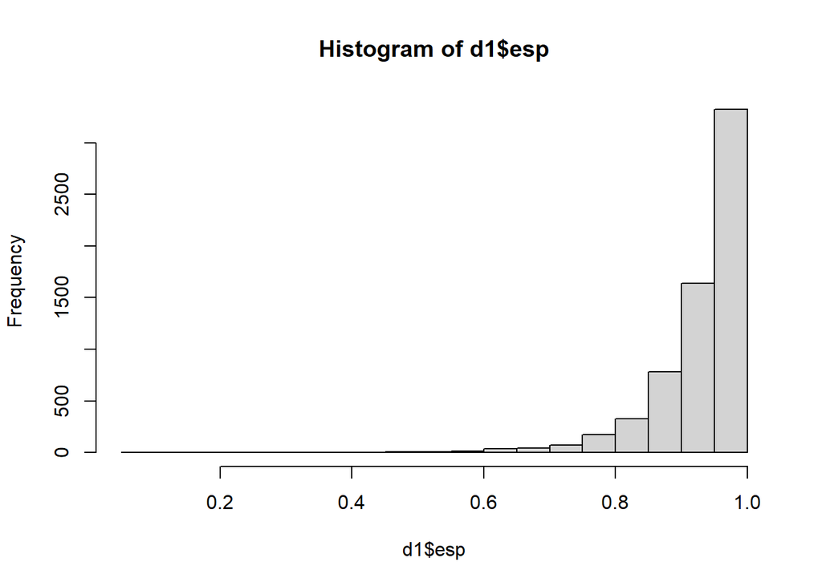

```r
hist(d1$esp)
```

#### Europeus

```r
summary(d1$euro)
```

```
##     Min.  1st Qu.   Median     Mean  3rd Qu.     Max.
## 0.000000 0.008825 0.022645 0.040836 0.050749 0.878378
```

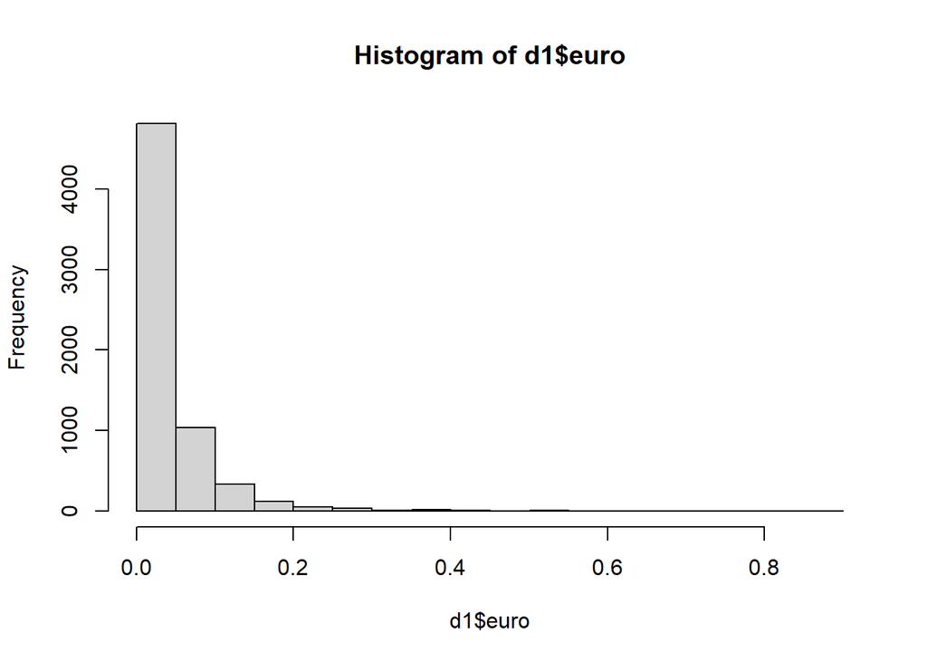

```r
hist(d1$euro)
```

#### Asiàtics

```r
summary(d1$asia)
```

```
##     Min.  1st Qu.   Median     Mean  3rd Qu.     Max.
## 0.000000 0.000000 0.000000 0.002046 0.002132 0.098901
```

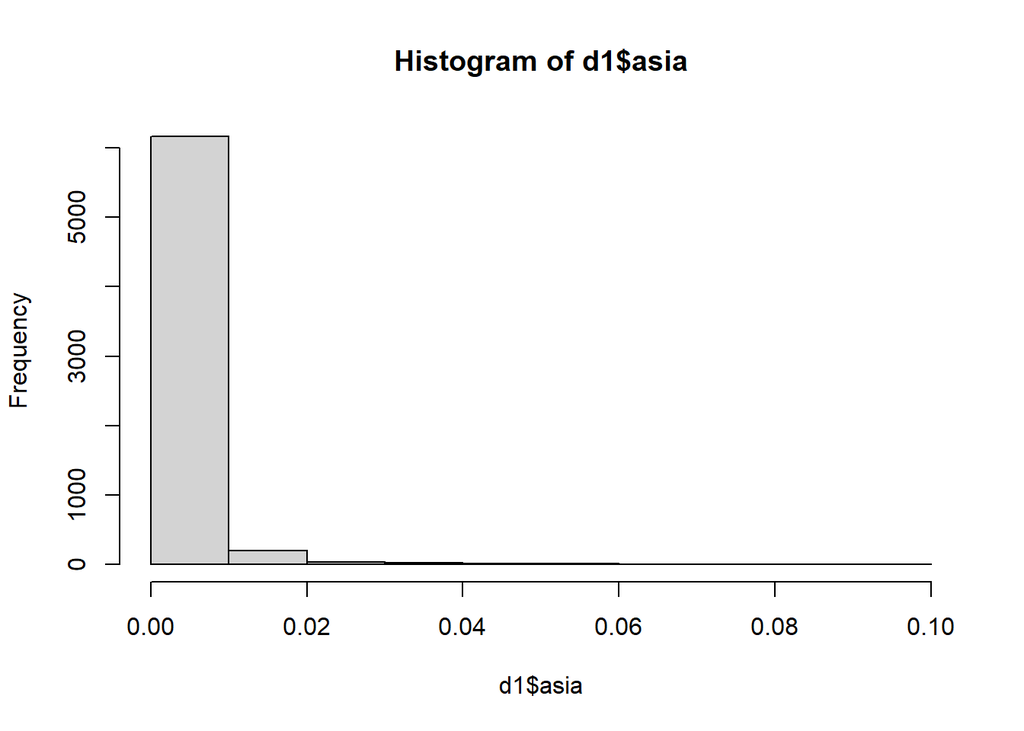

```r
hist(d1$asia)
```

#### Americans

```r
summary(d1$ame)
```

```
##     Min.  1st Qu.   Median     Mean  3rd Qu.     Max.
## 0.000000 0.003030 0.007752 0.011325 0.015874 0.154550
```

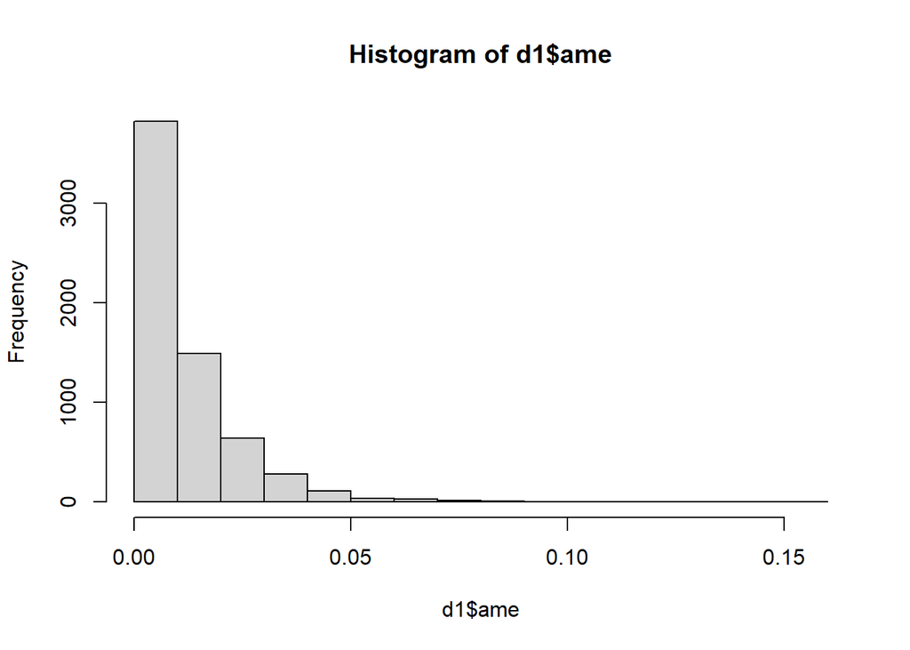

```r
hist(d1$ame)
```

#### Unió Europea

```r
summary(d1$UE)
```

```
##    Min. 1st Qu.  Median    Mean 3rd Qu.    Max.
## 0.00000 0.00800 0.02047 0.03808 0.04635 0.87331
```

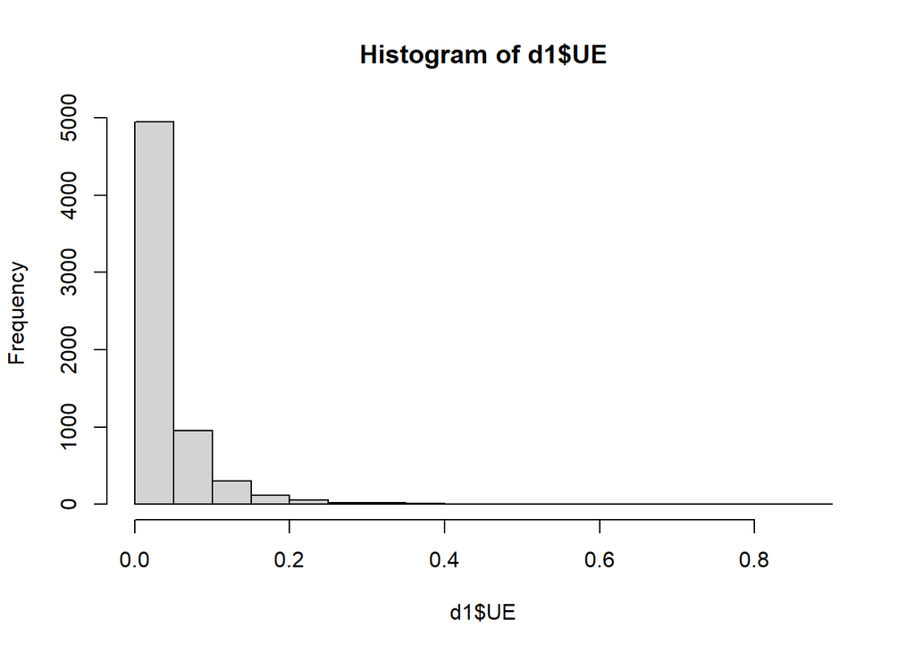

```r
hist(d1$UE)
```

#### Oceania i apàtrides

```r
summary(d1$oce_apa)
```

```
##      Min.   1st Qu.    Median      Mean   3rd Qu.      Max.
## 0.000e+00 0.000e+00 0.000e+00 7.676e-05 0.000e+00 1.442e-02
```

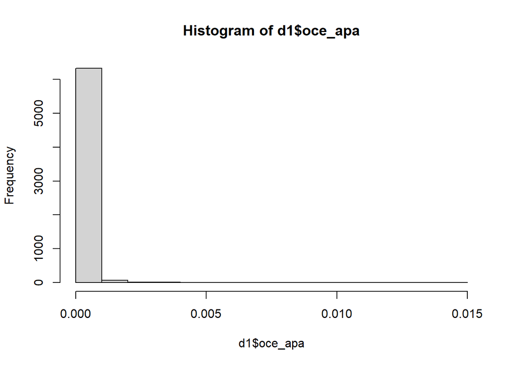

```r
hist(d1$oce_apa)
```

### 2.1.4. Sexe

#### Homes

```r
summary(d1$h)
```

```
##    Min. 1st Qu.  Median    Mean 3rd Qu.    Max.
##  0.3457  0.4985  0.5117  0.5190  0.5325  0.7021
```

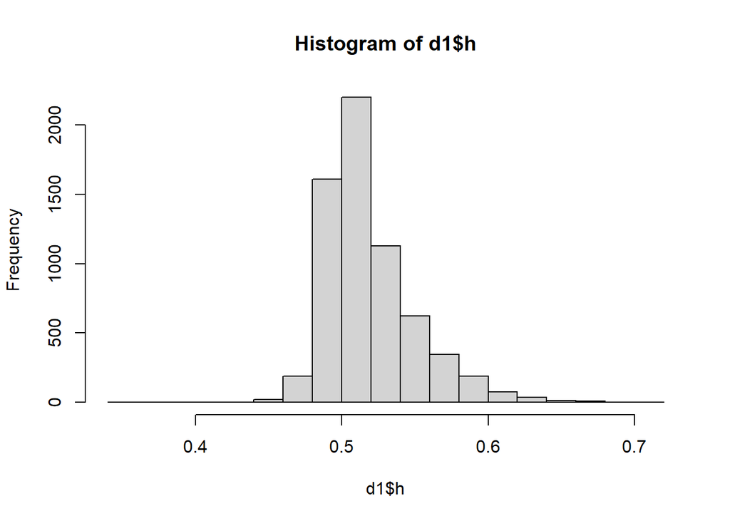

```r
hist(d1$h)
```

#### Dones

```r
summary(d1$m)
```

```
##    Min. 1st Qu.  Median    Mean 3rd Qu.    Max.
##  0.2979  0.4675  0.4883  0.4810  0.5015  0.6543
```

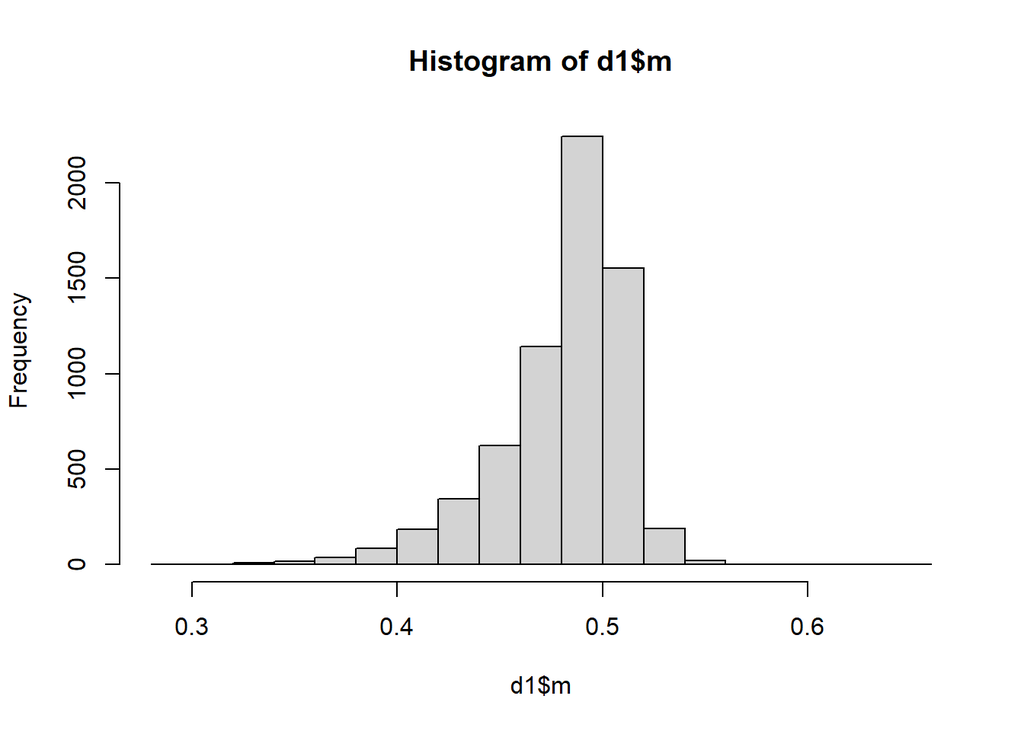

```r
hist(d1$m)
```

## 2.2. Anàlisi bivariant

### 2.2.1. Vot a Vox i atur

```r
d2 <- d1 %>% filter(atur > 0, VOX > 0)
```

```r
cor(d2$atur,d2$VOX)
```

```
## [1] 0.1996308
```

```r
cor(log(d2$atur), logit(d2$VOX))
```

```
## [1] 0.2530929
```

```r
cor((d2$atur),logit(d2$VOX))
```

```
## [1] 0.2607664
```

```r
cor(d2$atur, log(d2$VOX))
```

```
## [1] 0.2638057
```

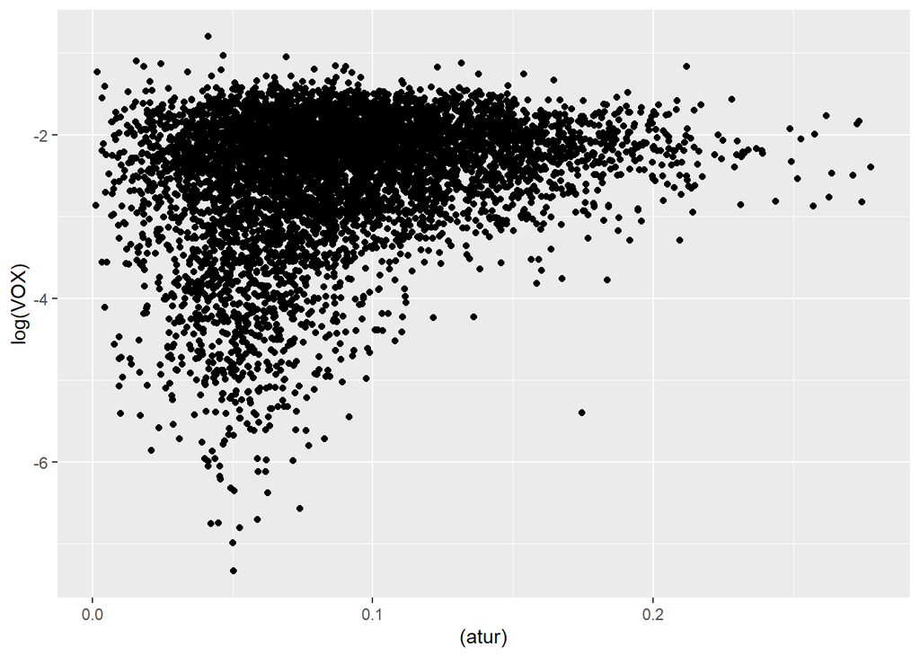

```r
d2 %>% ggplot(aes(x = (atur), y = log(VOX))) +
  geom_point()
```

### Propensió de l’atur

```r
 quantile(d2$atur, seq(0,1,0.2))
```

```
##          0%         20%         40%         60%         80%        100%
## 0.001282051 0.052897247 0.072099694 0.092767837 0.121471869 0.277777778
```

```r
d2 <- d2 %>%
  mutate(atur_t = cut(atur, c(-Inf, 0.005, 0.007, 0.009, 0.12, Inf )))

d2 %>% count(atur_t)
```

```
##          atur_t    n
## 1  (-Inf,0.005]   10
## 2 (0.005,0.007]    4
## 3 (0.007,0.009]   11
## 4  (0.009,0.12] 4987
## 5   (0.12, Inf] 1310
```

```r
PROPEN <- d2 %>%
  group_by(atur_t) %>%
  summarise(freq_absolutes = n()
    ,I_minim = minInt_bin(VOX )
         ,propensio = mean(VOX )
         ,I_maxim = maxInt_bin(VOX ))%>%
  mutate(freq_relatives = freq_absolutes / sum(freq_absolutes))
PROPEN
```

```
## # A tibble: 5 x 6
##   atur_t        freq_absolutes I_minim propensio I_maxim freq_relatives
##   <fct>                  <int>   <dbl>     <dbl>   <dbl>          <dbl>
## 1 (-Inf,0.005]              10 -0.0798    0.126    0.331       0.00158
## 2 (0.005,0.007]              4 -0.186     0.0804   0.347       0.000633
## 3 (0.007,0.009]             11 -0.0765    0.104    0.284       0.00174
## 4 (0.009,0.12]            4987  0.0911    0.0994   0.108       0.789
## 5 (0.12, Inf]             1310  0.102     0.119    0.137       0.207
```

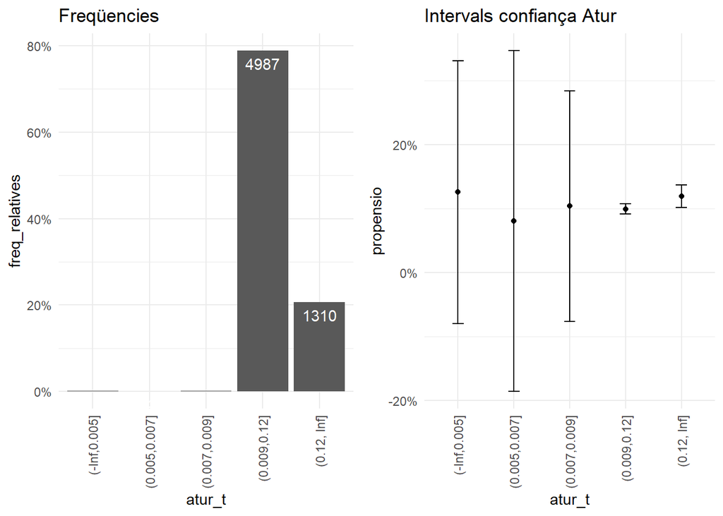

```r
p1 <- PROPEN %>%
  ggplot(aes(atur_t , freq_relatives)) +
  geom_bar(stat="identity")+
  geom_text(aes(label = freq_absolutes), vjust=1.6, color="white")+
  scale_y_continuous(labels = percent)+
  theme_minimal()+
  theme(axis.text.x = element_text(angle = 90, vjust = 0.5, hjust=1))+
  labs(title="Freqüencies")

p2 <- PROPEN %>%
  ggplot(aes(atur_t, propensio)) +
  geom_point(size = 1.5) +
  geom_errorbar(aes(ymin =I_minim, ymax = I_maxim, width = .2))+
  scale_y_continuous(labels = percent)+
  theme_minimal()+
  theme(axis.text.x = element_text(angle = 90, vjust = 0.5, hjust=1))+
  labs(title="Intervals confiança Atur")

plot_grid(p1, p2, ncol=2)
```

*** Queda pendent estudis posteriors sobre el valor 0

#### 2.2.1.1. Vot a Vox i atur dels menors de 24 anys

```r
cor(d2$atur_m24,d2$VOX, use = "pairwise.complete.obs")
```

```
## [1] 0.1700317
```

```r
cor(logit(d2$atur_m24),logit(d2$VOX), use = "pairwise.complete.obs")
```

```
## [1] 0.17627
```

```r
cor(d2$atur_m24,logit(d2$VOX), use = "pairwise.complete.obs")
```

```
## [1] 0.2152908
```

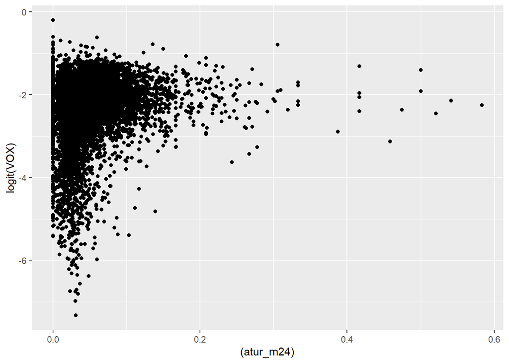

```r
d2 %>% ggplot(aes(x = (atur_m24), y = logit(VOX)))+
  geom_point()
```

```r
 quantile(d2$atur_m24, seq(0,1,0.2))
```

```
##         0%        20%        40%        60%        80%       100%
## 0.00000000 0.02011162 0.03703704 0.05555556 0.08041996 0.58333333
```

```r
d2 <- d2 %>%
  mutate(atur_m24t = cut(atur_m24, c(-Inf, 0.02, 0.04, 0.05, 0.08, Inf )))

d2 %>% count(atur_m24t)
```

```
##     atur_m24t    n
## 1 (-Inf,0.02] 1262
## 2 (0.02,0.04] 1469
## 3 (0.04,0.05]  706
## 4 (0.05,0.08] 1609
## 5 (0.08, Inf] 1276
```

###Propensió atur dels menors de 24 anys

```r
PROPEN4 <- d2 %>%
  group_by(atur_m24t) %>%
  summarise(freq_absolutes = n()
    ,I_minim = minInt_bin(VOX )
         ,propensio = mean(VOX )
         ,I_maxim = maxInt_bin(VOX ))%>%
  mutate(freq_relatives = freq_absolutes / sum(freq_absolutes))
PROPEN4
```

```
## # A tibble: 5 x 6
##   atur_m24t   freq_absolutes I_minim propensio I_maxim freq_relatives
##   <fct>                <int>   <dbl>     <dbl>   <dbl>          <dbl>
## 1 (-Inf,0.02]           1262  0.0750    0.0909  0.107           0.200
## 2 (0.02,0.04]           1469  0.0691    0.0833  0.0974          0.232
## 3 (0.04,0.05]            706  0.0849    0.108   0.131           0.112
## 4 (0.05,0.08]           1609  0.103     0.119   0.135           0.255
## 5 (0.08, Inf]           1276  0.0998    0.117   0.135           0.202
```

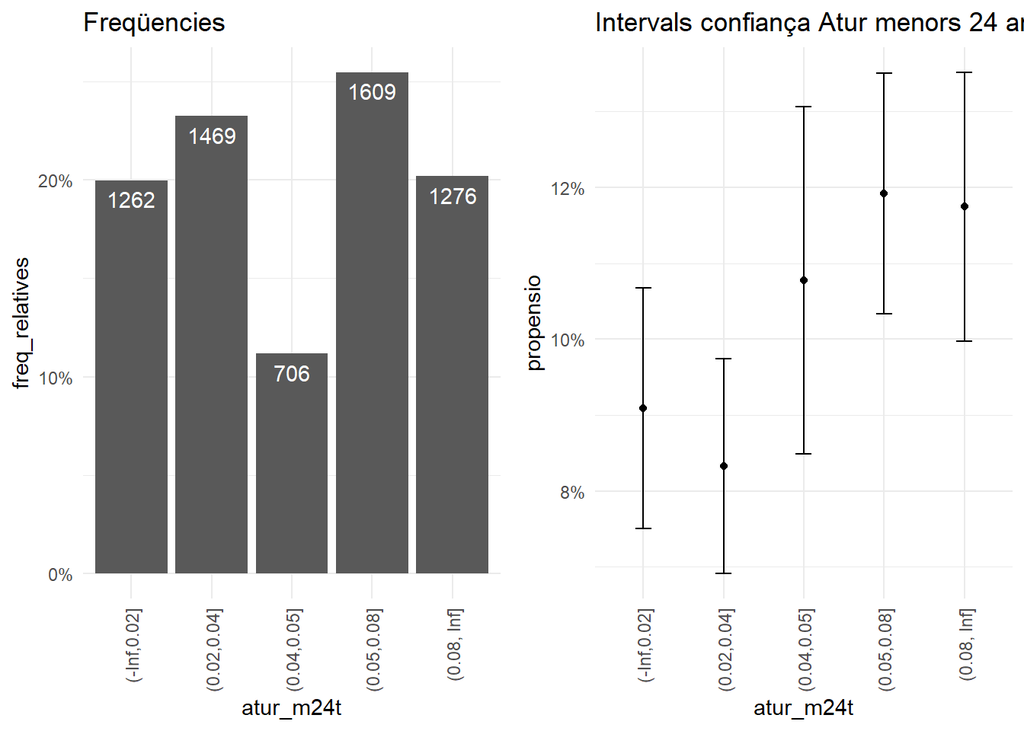

```r
p7 <- PROPEN4 %>%
  ggplot(aes(atur_m24t , freq_relatives)) +
  geom_bar(stat="identity")+
  geom_text(aes(label = freq_absolutes), vjust=1.6, color="white")+
  scale_y_continuous(labels = percent)+
  theme_minimal()+
  theme(axis.text.x = element_text(angle = 90, vjust = 0.5, hjust=1))+
  labs(title="Freqüencies")

p8 <- PROPEN4 %>%
  ggplot(aes(atur_m24t, propensio)) +
  geom_point(size = 1.5) +
  geom_errorbar(aes(ymin =I_minim, ymax = I_maxim, width = .2))+
  scale_y_continuous(labels = percent)+
  theme_minimal()+
  theme(axis.text.x = element_text(angle = 90, vjust = 0.5, hjust=1))+
  labs(title="Intervals confiança Atur menors 24 anys")

plot_grid(p7, p8, ncol=2)
```

#### 2.2.1.2. Vot a Vox i atur de persones entre 25 y 44 anys

```r
cor(d2$atur_25_44,d2$VOX)
```

```
## [1] 0.1761566
```

```r
cor(logit(d2$atur_25_44),logit(d2$VOX), use = "pairwise.complete.obs")
```

```
## [1] 0.1881515
```

```r
cor(d2$atur_25_44,logit(d2$VOX), use = "pairwise.complete.obs")
```

```
## [1] 0.2264125
```

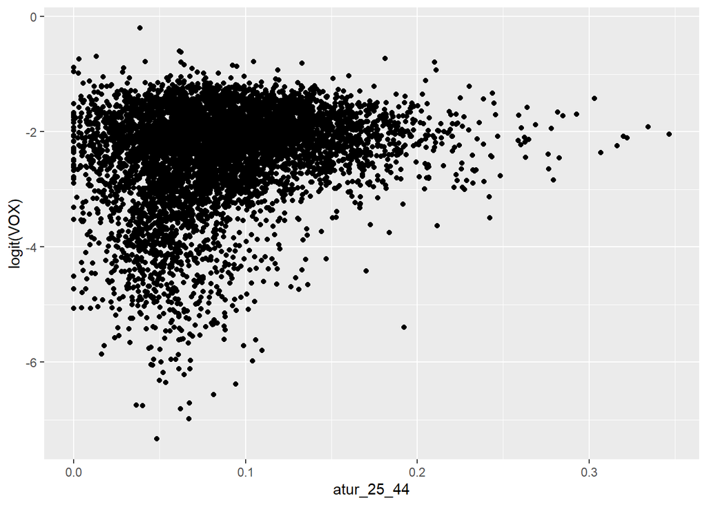

```r
d2 %>% ggplot(aes(x = atur_25_44, y = logit(VOX)))+
  geom_point()
```

###Propensió atur de persones entre 25 y 44 anys

```r
 quantile(d2$atur_25_44, seq(0,1,0.2))
```

```
##         0%        20%        40%        60%        80%       100%
## 0.00000000 0.04888453 0.07038067 0.09123261 0.12205172 0.34677419
```

```r
d2 <- d2 %>%
  mutate(atur_25_44t = cut(atur_25_44, c(-Inf, 0.05, 0.07, 0.09, 0.12, Inf )))
d2 %>% count(atur_25_44t)
```

```
##   atur_25_44t    n
## 1 (-Inf,0.05] 1343
## 2 (0.05,0.07] 1172
## 3 (0.07,0.09] 1190
## 4 (0.09,0.12] 1292
## 5 (0.12, Inf] 1325
```

```r
PROPEN5 <- d2 %>%
  group_by(atur_25_44t) %>%
  summarise(freq_absolutes = n()
    ,I_minim = minInt_bin(VOX )
         ,propensio = mean(VOX )
         ,I_maxim = maxInt_bin(VOX ))%>%
  mutate(freq_relatives = freq_absolutes / sum(freq_absolutes))
PROPEN5
```

```
## # A tibble: 5 x 6
##   atur_25_44t freq_absolutes I_minim propensio I_maxim freq_relatives
##   <fct>                <int>   <dbl>     <dbl>   <dbl>          <dbl>
## 1 (-Inf,0.05]           1343  0.0728    0.0879   0.103          0.212
## 2 (0.05,0.07]           1172  0.0761    0.0927   0.109          0.185
## 3 (0.07,0.09]           1190  0.0877    0.105    0.123          0.188
## 4 (0.09,0.12]           1292  0.0963    0.114    0.131          0.204
## 5 (0.12, Inf]           1325  0.100     0.118    0.135          0.210
```

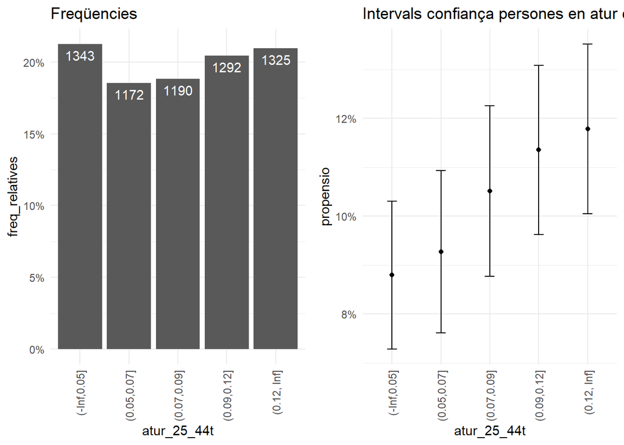

```r
p9 <- PROPEN5 %>%
  ggplot(aes(atur_25_44t , freq_relatives)) +
  geom_bar(stat="identity")+
  geom_text(aes(label = freq_absolutes), vjust=1.6, color="white")+
  scale_y_continuous(labels = percent)+
  theme_minimal()+
  theme(axis.text.x = element_text(angle = 90, vjust = 0.5, hjust=1))+
  labs(title="Freqüencies")

p10 <- PROPEN5 %>%
  ggplot(aes(atur_25_44t, propensio)) +
  geom_point(size = 1.5) +
  geom_errorbar(aes(ymin =I_minim, ymax = I_maxim, width = .2))+
  scale_y_continuous(labels = percent)+
  theme_minimal()+
  theme(axis.text.x = element_text(angle = 90, vjust = 0.5, hjust=1))+
  labs(title="Intervals confiança persones en atur entre 25 i 44 anys")

plot_grid(p9, p10, ncol=2)
```

#### 2.2.1.3. Vot a Vox i atur de majors de 45 anys

```r
cor(d2$atur_M45,d2$VOX)
```

```
## [1] 0.1844595
```

```r
cor(logit(d2$atur_M45),logit(d2$VOX), use = "pairwise.complete.obs")
```

```
## [1] 0.2010924
```

```r
cor(d2$atur_M45,logit(d2$VOX), use = "pairwise.complete.obs")
```

```
## [1] 0.2369323
```

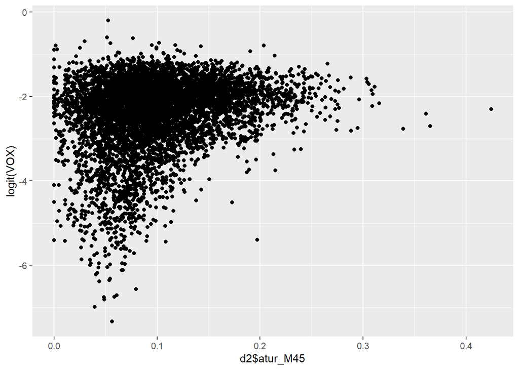

```r
d2 %>% ggplot(aes(x = d2$atur_M45, y = logit(VOX)))+
  geom_point()
```

###Propensió atur de majors de 45 anys

```r
 quantile(d2$atur_M45, seq(0,1,0.2))
```

```
##         0%        20%        40%        60%        80%       100%
## 0.00000000 0.05663666 0.08101405 0.10453481 0.13938552 0.42460317
```

```r
d2 <- d2 %>%
  mutate(atur_M45t = cut(atur_M45, c(-Inf, 0.06, 0.08, 0.10, 0.14, Inf )))
d2 %>% count(atur_M45t)
```

```
##     atur_M45t    n
## 1 (-Inf,0.06] 1410
## 2 (0.06,0.08] 1070
## 3  (0.08,0.1] 1098
## 4  (0.1,0.14] 1495
## 5 (0.14, Inf] 1249
```

```r
PROPEN6 <- d2 %>%
  group_by(atur_M45t) %>%
  summarise(freq_absolutes = n()
    ,I_minim = minInt_bin(VOX )
         ,propensio = mean(VOX )
         ,I_maxim = maxInt_bin(VOX ))%>%
  mutate(freq_relatives = freq_absolutes / sum(freq_absolutes))
PROPEN6
```

```
## # A tibble: 5 x 6
##   atur_M45t   freq_absolutes I_minim propensio I_maxim freq_relatives
##   <fct>                <int>   <dbl>     <dbl>   <dbl>          <dbl>
## 1 (-Inf,0.06]           1410  0.0746    0.0895   0.104          0.223
## 2 (0.06,0.08]           1070  0.0770    0.0946   0.112          0.169
## 3 (0.08,0.1]            1098  0.0844    0.102    0.120          0.174
## 4 (0.1,0.14]            1495  0.0945    0.110    0.126          0.236
## 5 (0.14, Inf]           1249  0.102     0.120    0.138          0.198
```

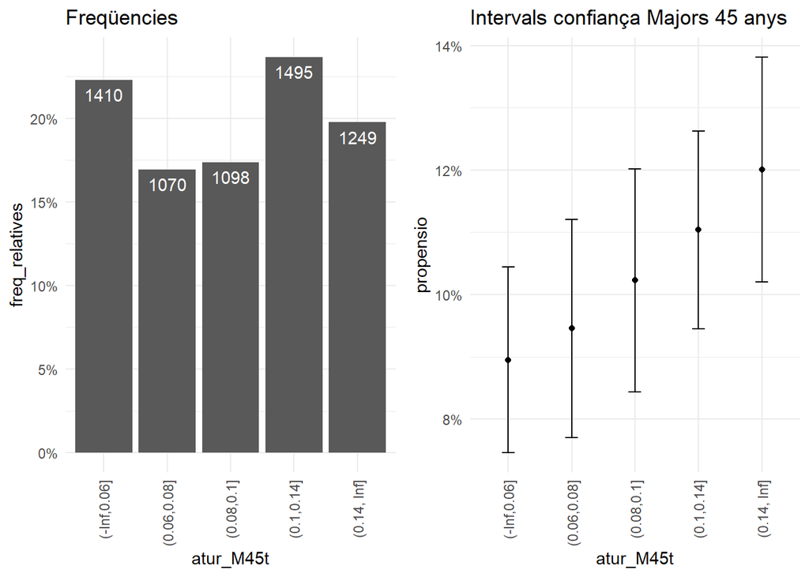

```r
p11 <- PROPEN6 %>%
  ggplot(aes(atur_M45t , freq_relatives)) +
  geom_bar(stat="identity")+
  geom_text(aes(label = freq_absolutes), vjust=1.6, color="white")+
  scale_y_continuous(labels = percent)+
  theme_minimal()+
  theme(axis.text.x = element_text(angle = 90, vjust = 0.5, hjust=1))+
  labs(title="Freqüencies")

p12 <- PROPEN6 %>%
  ggplot(aes(atur_M45t, propensio)) +
  geom_point(size = 1.5) +
  geom_errorbar(aes(ymin =I_minim, ymax = I_maxim, width = .2))+
  scale_y_continuous(labels = percent)+
  theme_minimal()+
  theme(axis.text.x = element_text(angle = 90, vjust = 0.5, hjust=1))+
  labs(title="Intervals confiança Majors 45 anys")

plot_grid(p11, p12, ncol=2)
```

### 2.2.2. Vot a Vox i edat

```r
d2 %>%
  mutate(logit_VOX = logit(VOX)
         ,m29 = m19 + e20_29) %>%
  select(m29, e30_39, e40_49, e50_59, e60_69, e70_79, M80, logit_VOX, VOX) %>%
  cor()
```

```
##                   m29      e30_39      e40_49      e50_59      e60_69
## m29        1.00000000  0.66214699  0.60603067 -0.32742005 -0.69254006
## e30_39     0.66214699  1.00000000  0.45267834 -0.39357321 -0.44005331
## e40_49     0.60603067  0.45267834  1.00000000 -0.33107348 -0.57429405
## e50_59    -0.32742005 -0.39357321 -0.33107348  1.00000000  0.17842565
## e60_69    -0.69254006 -0.44005331 -0.57429405  0.17842565  1.00000000
## e70_79    -0.81087686 -0.64637619 -0.58319247  0.03717047  0.53724211
## M80       -0.84211908 -0.69296448 -0.69620043  0.19716161  0.44411637
## logit_VOX -0.02997110  0.03861837 -0.03480903  0.05532392 -0.06755104
## VOX        0.04932834  0.10020407  0.03843048  0.02491326 -0.10859528
##                e70_79         M80   logit_VOX         VOX
## m29       -0.81087686 -0.84211908 -0.02997110  0.04932834
## e30_39    -0.64637619 -0.69296448  0.03861837  0.10020407
## e40_49    -0.58319247 -0.69620043 -0.03480903  0.03843048
## e50_59     0.03717047  0.19716161  0.05532392  0.02491326
## e60_69     0.53724211  0.44411637 -0.06755104 -0.10859528
## e70_79     1.00000000  0.68689894  0.01500536 -0.06287652
## M80        0.68689894  1.00000000  0.04142835 -0.03900435
## logit_VOX  0.01500536  0.04142835  1.00000000  0.90285519
## VOX       -0.06287652 -0.03900435  0.90285519  1.00000000
```

```r
 d2$logit_VOX <- logit(d2$VOX)
d2$m29 <- d2$m19 + d2$e20_29
```

### 2.2.2.1 Vot a Vox i menors 29 anys

```r
cor(d2$m29,d2$VOX)
```

```
## [1] 0.04932834
```

```r
cor(logit(d2$m29),logit(d2$VOX), use = "pairwise.complete.obs")
```

```
## [1] -0.0422594
```

```r
cor(d2$m29,logit(d2$VOX), use = "pairwise.complete.obs")
```

```
## [1] -0.0299711
```

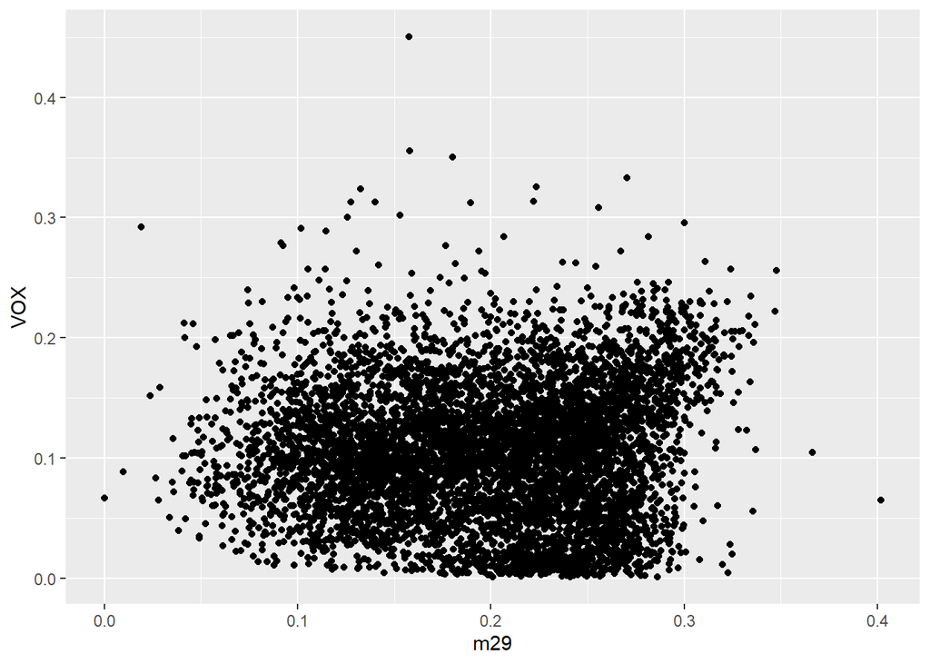

```r
d2 %>% ggplot(aes(x = m29, y = VOX))+
  geom_point()
```

### Propensión del vot a Vox i menors 29 anys

```r
 quantile(d2$m29, seq(0,1,0.2))
```

```
##        0%       20%       40%       60%       80%      100%
## 0.0000000 0.1383616 0.1831601 0.2229591 0.2545142 0.4017094
```

```r
d2 <- d2 %>%
  mutate(m29t = cut(m29, c(-Inf, 0.14, 0.18, 0.22, 0.25, Inf )))

d2 %>% count(m29t)
```

```
##          m29t    n
## 1 (-Inf,0.14] 1306
## 2 (0.14,0.18] 1136
## 3 (0.18,0.22] 1236
## 4 (0.22,0.25] 1200
## 5 (0.25, Inf] 1444
```

```r
PROPEN9 <- d2 %>%
  group_by(m29t) %>%
  summarise(freq_absolutes = n()
    ,I_minim = minInt_bin(VOX )
         ,propensio = mean(VOX )
         ,I_maxim = maxInt_bin(VOX ))%>%
  mutate(freq_relatives = freq_absolutes / sum(freq_absolutes))
PROPEN9
```

```
## # A tibble: 5 x 6
##   m29t        freq_absolutes I_minim propensio I_maxim freq_relatives
##   <fct>                <int>   <dbl>     <dbl>   <dbl>          <dbl>
## 1 (-Inf,0.14]           1306  0.0880    0.105    0.121          0.207
## 2 (0.14,0.18]           1136  0.0869    0.105    0.123          0.180
## 3 (0.18,0.22]           1236  0.0807    0.0972   0.114          0.196
## 4 (0.22,0.25]           1200  0.0765    0.0930   0.109          0.190
## 5 (0.25, Inf]           1444  0.0994    0.116    0.132          0.228
```

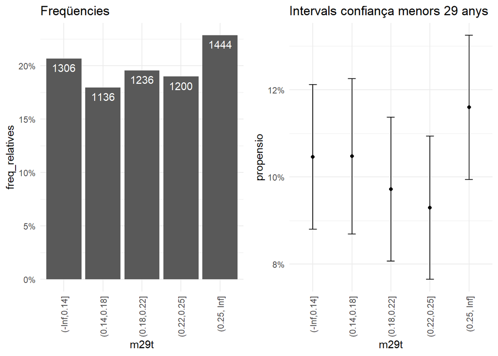

```r
p14 <- PROPEN9 %>%
  ggplot(aes(m29t , freq_relatives)) +
  geom_bar(stat="identity")+
  geom_text(aes(label = freq_absolutes), vjust=1.6, color="white")+
  scale_y_continuous(labels = percent)+
  theme_minimal()+
  theme(axis.text.x = element_text(angle = 90, vjust = 0.5, hjust=1))+
  labs(title="Freqüencies")

p15 <- PROPEN9 %>%
  ggplot(aes(m29t, propensio)) +
  geom_point(size = 1.5) +
  geom_errorbar(aes(ymin =I_minim, ymax = I_maxim, width = .2))+
  scale_y_continuous(labels = percent)+
  theme_minimal()+
  theme(axis.text.x = element_text(angle = 90, vjust = 0.5, hjust=1))+
  labs(title="Intervals confiança menors 29 anys")

plot_grid(p14, p15, ncol=2)
```

### 2.2.2.2 Vot a Vox i edat 30 - 39

```r
cor(d2$e30_39,d2$VOX)
```

```
## [1] 0.1002041
```

```r
cor(logit(d2$e30_39),logit(d2$VOX), use = "pairwise.complete.obs")
```

```
## [1] 0.01334474
```

```r
cor(d2$e30_39,logit(d2$VOX), use = "pairwise.complete.obs")
```

```
## [1] 0.03861837
```

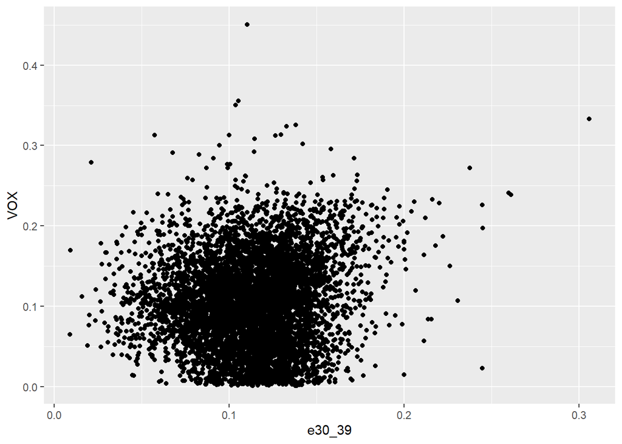

```r
d2 %>% ggplot(aes(x = e30_39, y = VOX))+
  geom_point()
```

### Propensión del vot a Vox i edat 30 - 39 anys

```r
 quantile(d2$e30_39, seq(0,1,0.2))
```

```
##          0%         20%         40%         60%         80%        100%
## 0.008849558 0.090909091 0.109189426 0.122479598 0.135470018 0.305743243
```

```r
d2 <- d2 %>%
  mutate(e30_39t = cut(e30_39, c(-Inf, 0.09, 0.11, 0.12, 0.14, Inf )))

d2 %>% count(e30_39t)
```

```
##       e30_39t    n
## 1 (-Inf,0.09] 1212
## 2 (0.09,0.11] 1380
## 3 (0.11,0.12]  956
## 4 (0.12,0.14] 1777
## 5 (0.14, Inf]  997
```

```r
PROPEN10 <- d2 %>%
  group_by(e30_39t) %>%
  summarise(freq_absolutes = n()
    ,I_minim = minInt_bin(VOX )
         ,propensio = mean(VOX )
         ,I_maxim = maxInt_bin(VOX ))%>%
  mutate(freq_relatives = freq_absolutes / sum(freq_absolutes))
PROPEN10
```

```
## # A tibble: 5 x 6
##   e30_39t     freq_absolutes I_minim propensio I_maxim freq_relatives
##   <fct>                <int>   <dbl>     <dbl>   <dbl>          <dbl>
## 1 (-Inf,0.09]           1212  0.0859    0.103    0.120          0.192
## 2 (0.09,0.11]           1380  0.0845    0.100    0.116          0.218
## 3 (0.11,0.12]            956  0.0767    0.0954   0.114          0.151
## 4 (0.12,0.14]           1777  0.0869    0.101    0.115          0.281
## 5 (0.14, Inf]            997  0.101     0.121    0.142          0.158
```

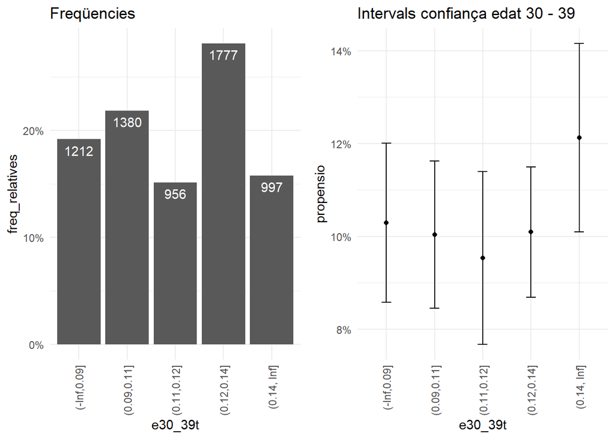

```r
p16 <- PROPEN10 %>%
  ggplot(aes(e30_39t , freq_relatives)) +
  geom_bar(stat="identity")+
  geom_text(aes(label = freq_absolutes), vjust=1.6, color="white")+
  scale_y_continuous(labels = percent)+
  theme_minimal()+
  theme(axis.text.x = element_text(angle = 90, vjust = 0.5, hjust=1))+
  labs(title="Freqüencies")

p17 <- PROPEN10 %>%
  ggplot(aes(e30_39t, propensio)) +
  geom_point(size = 1.5) +
  geom_errorbar(aes(ymin =I_minim, ymax = I_maxim, width = .2))+
  scale_y_continuous(labels = percent)+
  theme_minimal()+
  theme(axis.text.x = element_text(angle = 90, vjust = 0.5, hjust=1))+
  labs(title="Intervals confiança edat 30 - 39")

plot_grid(p16, p17, ncol=2)
```

### 2.2.2.3 Vot a Vox i edat 40 - 49

```r
cor(d2$e40_49,d2$VOX)
```

```
## [1] 0.03843048
```

```r
cor(logit(d2$e40_49),logit(d2$VOX), use = "pairwise.complete.obs")
```

```
## [1] -0.04312601
```

```r
cor(d2$e40_49,logit(d2$VOX), use = "pairwise.complete.obs")
```

```
## [1] -0.03480903
```

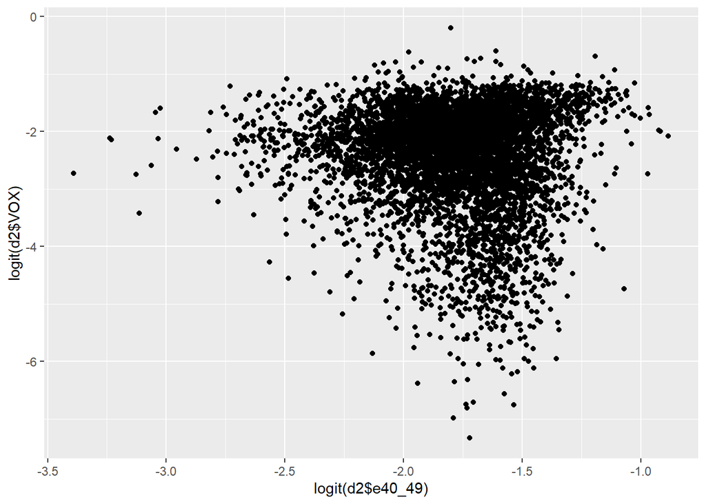

```r
d2 %>% ggplot(aes(x = logit(d2$e40_49), y = logit(d2$VOX)))+
  geom_point()
```

### Propensión del vot a Vox i edat 40 - 49 anys

```r
 quantile(d2$e40_49, seq(0,1,0.2))
```

```
##        0%       20%       40%       60%       80%      100%
## 0.0326087 0.1206069 0.1392173 0.1558442 0.1735694 0.2924528
```

```r
d2 <- d2 %>%
  mutate(e40_49t = cut(e40_49, c(-Inf, 0.12, 0.14, 0.16, 0.17, Inf )))

d2 %>% count(e40_49t)
```

```
##       e40_49t    n
## 1 (-Inf,0.12] 1240
## 2 (0.12,0.14] 1340
## 3 (0.14,0.16] 1518
## 4 (0.16,0.17]  721
## 5 (0.17, Inf] 1503
```

```r
PROPEN11 <- d2 %>%
  group_by(e40_49t) %>%
  summarise(freq_absolutes = n()
    ,I_minim = minInt_bin(VOX )
         ,propensio = mean(VOX )
         ,I_maxim = maxInt_bin(VOX ))%>%
  mutate(freq_relatives = freq_absolutes / sum(freq_absolutes))
PROPEN11
```

```
## # A tibble: 5 x 6
##   e40_49t     freq_absolutes I_minim propensio I_maxim freq_relatives
##   <fct>                <int>   <dbl>     <dbl>   <dbl>          <dbl>
## 1 (-Inf,0.12]           1240  0.0886     0.106   0.123          0.196
## 2 (0.12,0.14]           1340  0.0876     0.104   0.120          0.212
## 3 (0.14,0.16]           1518  0.0852     0.100   0.115          0.240
## 4 (0.16,0.17]            721  0.0782     0.100   0.122          0.114
## 5 (0.17, Inf]           1503  0.0909     0.106   0.122          0.238
```

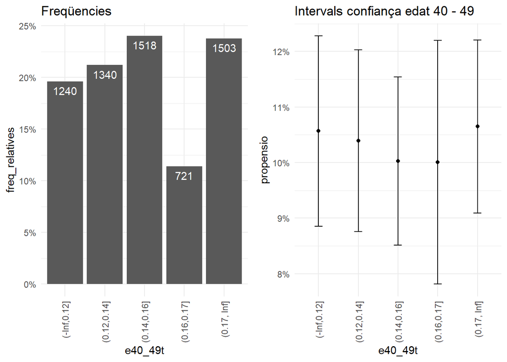

```r
p18 <- PROPEN11 %>%
  ggplot(aes(e40_49t , freq_relatives)) +
  geom_bar(stat="identity")+
  geom_text(aes(label = freq_absolutes), vjust=1.6, color="white")+
  scale_y_continuous(labels = percent)+
  theme_minimal()+
  theme(axis.text.x = element_text(angle = 90, vjust = 0.5, hjust=1))+
  labs(title="Freqüencies")

p19 <- PROPEN11 %>%
  ggplot(aes(e40_49t, propensio)) +
  geom_point(size = 1.5) +
  geom_errorbar(aes(ymin =I_minim, ymax = I_maxim, width = .2))+
  scale_y_continuous(labels = percent)+
  theme_minimal()+
  theme(axis.text.x = element_text(angle = 90, vjust = 0.5, hjust=1))+
  labs(title="Intervals confiança edat 40 - 49")

plot_grid(p18, p19, ncol=2)
```

### 2.2.2.4 Vot a Vox i edat 50 - 59

```r
cor(d2$e50_59,d2$VOX)
```

```
## [1] 0.02491326
```

```r
cor(logit(d2$e50_59),logit(d2$VOX), use = "pairwise.complete.obs")
```

```
## [1] 0.04888718
```

```r
cor(d2$e50_59,logit(d2$VOX), use = "pairwise.complete.obs")
```

```
## [1] 0.05532392
```

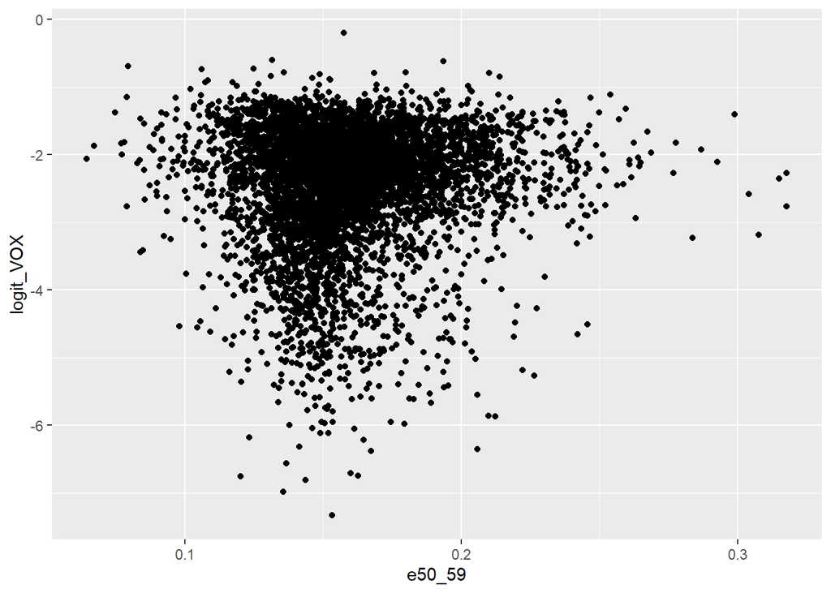

```r
d2 %>% ggplot(aes(x = e50_59, y = logit_VOX))+
  geom_point()
```

### Propensión del vot a Vox i edat 50 - 59 anys

```r
 quantile(d2$e50_59, seq(0,1,0.2))
```

```
##         0%        20%        40%        60%        80%       100%
## 0.06451613 0.13962120 0.15091651 0.16166223 0.17819997 0.31782946
```

```r
d2 <- d2 %>%
  mutate(e50_59t = cut(e50_59, c(-Inf, 0.14, 0.15, 0.16, 0.18, Inf )))

d2 %>% count(e50_59t)
```

```
##       e50_59t    n
## 1 (-Inf,0.14] 1305
## 2 (0.14,0.15] 1094
## 3 (0.15,0.16] 1230
## 4 (0.16,0.18] 1528
## 5 (0.18, Inf] 1165
```

```r
PROPEN12 <- d2 %>%
  group_by(e50_59t) %>%
  summarise(freq_absolutes = n()
    ,I_minim = minInt_bin(VOX )
         ,propensio = mean(VOX )
         ,I_maxim = maxInt_bin(VOX ))%>%
  mutate(freq_relatives = freq_absolutes / sum(freq_absolutes))
PROPEN12
```

```
## # A tibble: 5 x 6
##   e50_59t     freq_absolutes I_minim propensio I_maxim freq_relatives
##   <fct>                <int>   <dbl>     <dbl>   <dbl>          <dbl>
## 1 (-Inf,0.14]           1305  0.0901    0.107    0.124          0.206
## 2 (0.14,0.15]           1094  0.0792    0.0967   0.114          0.173
## 3 (0.15,0.16]           1230  0.0823    0.0990   0.116          0.195
## 4 (0.16,0.18]           1528  0.0901    0.106    0.121          0.242
## 5 (0.18, Inf]           1165  0.0907    0.109    0.126          0.184
```

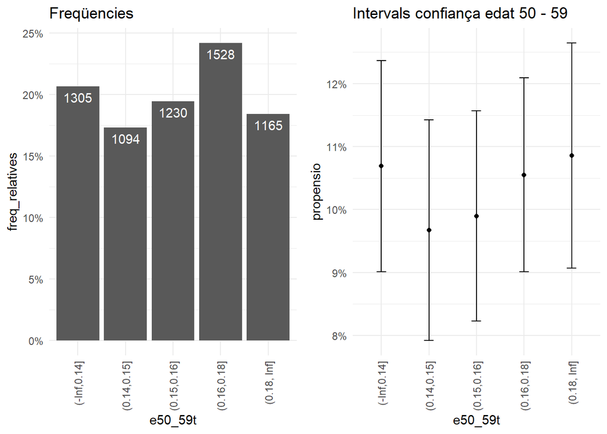

```r
p20 <- PROPEN12 %>%
  ggplot(aes(e50_59t , freq_relatives)) +
  geom_bar(stat="identity")+
  geom_text(aes(label = freq_absolutes), vjust=1.6, color="white")+
  scale_y_continuous(labels = percent)+
  theme_minimal()+
  theme(axis.text.x = element_text(angle = 90, vjust = 0.5, hjust=1))+
  labs(title="Freqüencies")

p21 <- PROPEN12 %>%
  ggplot(aes(e50_59t, propensio)) +
  geom_point(size = 1.5) +
  geom_errorbar(aes(ymin =I_minim, ymax = I_maxim, width = .2))+
  scale_y_continuous(labels = percent)+
  theme_minimal()+
  theme(axis.text.x = element_text(angle = 90, vjust = 0.5, hjust=1))+
  labs(title="Intervals confiança edat 50 - 59")

plot_grid(p20, p21, ncol=2)
```

### 2.2.2.5 Vot a Vox i edat 60 - 69

```r
cor(d2$e60_69,d2$VOX)
```

```
## [1] -0.1085953
```

```r
cor(logit(d2$e60_69),logit(d2$VOX), use = "pairwise.complete.obs")
```

```
## [1] -0.08871025
```

```r
cor(d2$e60_69,logit(d2$VOX), use = "pairwise.complete.obs")
```

```
## [1] -0.06755104
```

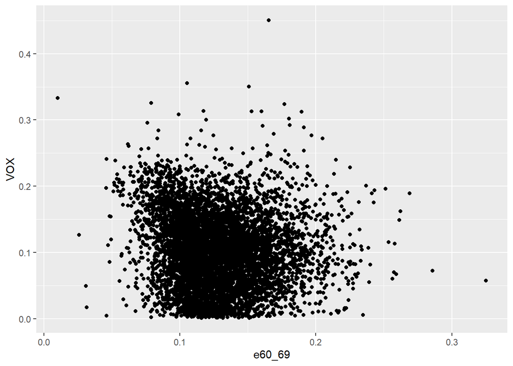

```r
d2 %>% ggplot(aes(x = e60_69, y = VOX))+
  geom_point()
```

### Propensión del vot a Vox i edat 60 - 69 anys

```r
 quantile(d2$e60_69, seq(0,1,0.2))
```

```
##         0%        20%        40%        60%        80%       100%
## 0.01013514 0.10260121 0.11643488 0.13232400 0.15302338 0.32500000
```

```r
d2 <- d2 %>%
  mutate(e60_69t = cut(e60_69, c(-Inf, 0.10, 0.12, 0.13, 0.15, Inf )))

d2 %>% count(e60_69t)
```

```
##       e60_69t    n
## 1  (-Inf,0.1] 1087
## 2  (0.1,0.12] 1767
## 3 (0.12,0.13]  759
## 4 (0.13,0.15] 1299
## 5 (0.15, Inf] 1410
```

```r
PROPEN13 <- d2 %>%
  group_by(e60_69t) %>%
  summarise(freq_absolutes = n()
    ,I_minim = minInt_bin(VOX )
         ,propensio = mean(VOX )
         ,I_maxim = maxInt_bin(VOX ))%>%
  mutate(freq_relatives = freq_absolutes / sum(freq_absolutes))
PROPEN13
```

```
## # A tibble: 5 x 6
##   e60_69t     freq_absolutes I_minim propensio I_maxim freq_relatives
##   <fct>                <int>   <dbl>     <dbl>   <dbl>          <dbl>
## 1 (-Inf,0.1]            1087  0.107     0.127    0.147          0.172
## 2 (0.1,0.12]            1767  0.0866    0.101    0.115          0.280
## 3 (0.12,0.13]            759  0.0738    0.0946   0.115          0.120
## 4 (0.13,0.15]           1299  0.0801    0.0961   0.112          0.205
## 5 (0.15, Inf]           1410  0.0854    0.101    0.117          0.223
```